# Section 9

Natalia Garbiras Díaz

March 24, 2017

# Today: MLE

- Stochastic and systematic components (example: logit)
- Deriving and plotting the likelihood function
- Finding the MLE and its SE
- Reporting MLE results

# The setup

- We are interested in estimating parameters of conditional distributions (e.g., $P(y_i =1 \mid X)$).
- Each random draw can be written as ($y_i$, $x_i$) $\rightarrow$ we want to estimate the conditional distribution of $y_i$ given $x_i$.
- In order to get the MLE, we need to first assume the underlying distribution of $y_i$ given $x_i$. That is why we have a *parametric* model with some finite number of unknown parameters that we need to estimate.
- With MLE we are looking for the parameter that maximizes the joint density of ($y_1, y_2, \cdots, y_N$) evaluated in the data.
- - Notice we are not interested in $x_i$ so we do not specify a model for how $x_i$ is generated. Alternatively, we could think of $x_i$ as non-random (i.e., fixed features of a population).
- Notice also that while $y_i$ is independent, it is not identically distributed (depends on $X\beta$).

# The DGP: Stochastic Component

PDF of a Bernoulli (binary) variable:

$$Y_i \sim Y_{Bern}(Y_i \mid \pi_i) = (\pi_i)^{y_i} (1-\pi_i)^{(1-y_i)}$$

where $y_i = \{0,1\}$.

Simplifies to $\pi_i$ if $y_i=1$ and $(1-\pi_i)$ if $y_i=0$.

But what is $\pi_i$? For that we need a *link* function.

# The Logistic Link Function

Systematic component (CDF):

$$\pi_i = F(x) = \Lambda(x) = \frac{1}{1+e^{-x}} = \frac{e^x}{1+e^x}$$

- Note that $\Lambda(x) \in [0,1]$ for all $x$

We can program this:

```r
logistic <- function(x){ exp(x) / (1 + exp(x)) }
```

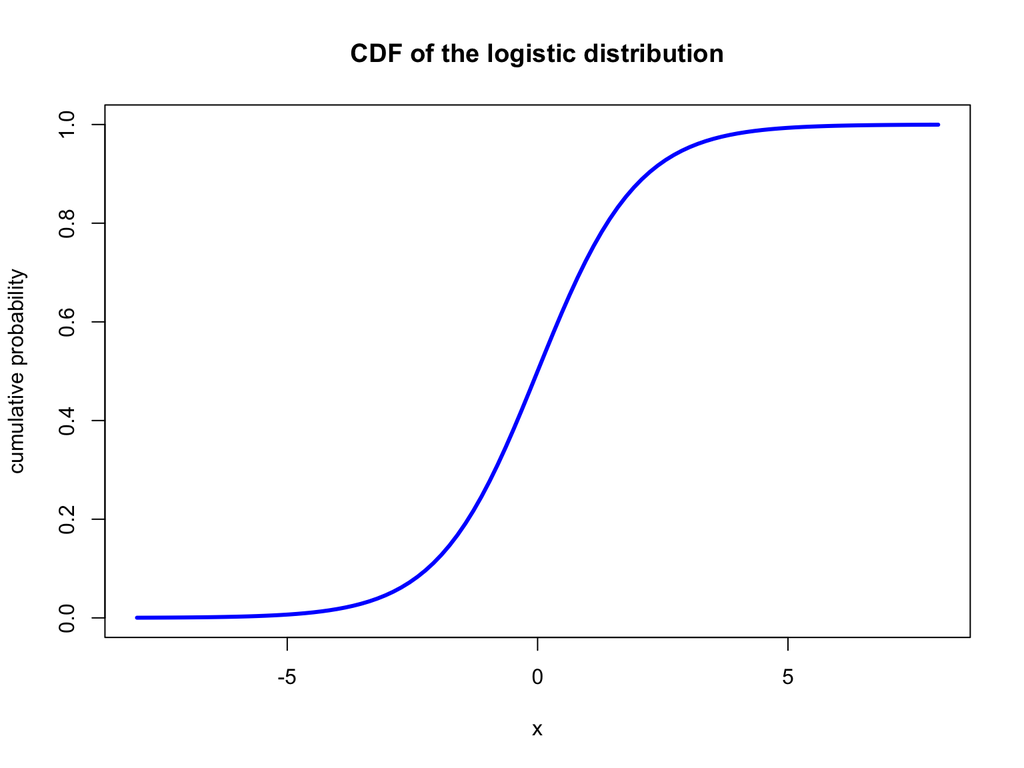

```r
curve(logistic(x), xlim=c(-8, 8), xlab="x", main="CDF of the logistic distribution",
      ylab="cumulative probability", col="blue", lwd=3)
```

$\Lambda$ is our link function: it filters the linear combination (i.e., our model with covariates) and returns 0-1 bounded probabilities.

So, with covariates, we have:

$$\Lambda = F(X\beta) = \frac{1}{1+e^{-X\beta}} = \frac{e^{X\beta}}{1+e^{X\beta}}$$

And:

$$P(y_i=1 \mid \beta) = \pi_i= \frac{1}{1+e^{-X\beta}}$$

$$P(y_i=0 \mid \beta) = 1 - \pi_i= 1 - (\frac{1}{1+e^{-X\beta}})$$

A small dataset

```r
Y <- c(1, 0, 1, 0, 0, 1, 1)
x <- c(.5, .3, .45, .4, .25, .7, .9)

cbind(Y, x)
```

```
##      Y    x
## [1,] 1 0.50
## [2,] 0 0.30
## [3,] 1 0.45
## [4,] 0 0.40
## [5,] 0 0.25
## [6,] 1 0.70
## [7,] 1 0.90
```

What is the joint probability distribution of these $n=7$ observations?

$$P(y \mid \pi) = \prod_{i=1}^{n} \pi^{y_i} (1-\pi_i)^{1-y_i}$$

where $\pi_i = F(x_i\beta) = \frac{1}{1+e^{-x_i\beta}}$

And so the likelihood is
$$L = P(y \mid X\beta) = \prod_{i=1}^{n} F(x_i\beta)^{y_i} (1-F(x_i\beta))^{1-y_i}$$

And the log-likelihood is
$$\ln L = \sum_{i=1}^{n} \big( y_i \times \ln [F(x_i\beta)] + (1-y_i) \times \ln [1-F(x_i\beta)] \big)$$

We can program the likelihood in `R`:

```r
LL <- function(beta, x, y){

    odds <- beta * x

    rate <- 1 / (1 + exp(-odds))

    sum( y * log(rate) + (1 - y) * log(1 - rate) )
}
```

And we can plot the log-likelihood of our fake data:

```r
LL_example <- function(x){

    odds <- x * c(.5, .3, .4, .4, .25) # here x is a placeholder for our vector of betas

    rate <- 1 / (1 + exp(-odds))

    y <- c(1, 0, 1, 0, 0)

    sum(ifelse(y==1, log(rate), log(1 - rate)))

}

betas <- seq(-10, 10, by=.01)
ll_betas <- unlist(lapply(betas, FUN=LL_example)) # no intercept here
```

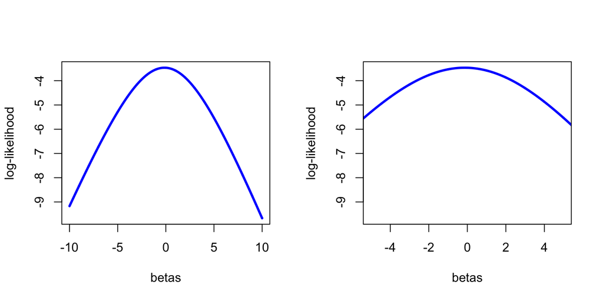

```r
par(mfrow=c(1,2))
plot(betas, ll_betas, col="blue", type="l", lwd=3, ylab="log-likelihood")
plot(betas, ll_betas, col="blue", type="l", lwd=3, ylab="log-likelihood", xlim=c(-5, 5))
```

What’s the value of $\beta$ tha maximizes the log-likelihood?

# Getting the MLE (computation search).

- For many MLE, we do not have an analytic or closed-form solution (under the assumptions of the OLS, we do have one for the linear model).
- But we know that the MLE is the maximizer of the log-likehood (and, thus, also maximizes the likelihood function).

```r
beta.start <- 0
out  <-  optim(beta.start,
            fn=LL,
            x=x,y=Y,
            hessian=T,
            method="L-BFGS-B", # stands for "Limited-memory Broyden-Fletcher-Goldfarb-Shanno"
            control=list(fnscale=-1))
out
```

```
## $par
## [1] 1.732208
##
## $value
## [1] -4.197606
##
## $counts
## function gradient
##        7        7
##
## $convergence
## [1] 0
##
## $message
## [1] "CONVERGENCE: REL_REDUCTION_OF_F <= FACTR*EPSMCH"
##
## $hessian
##            [,1]
## [1,] -0.3701616
```

[Interested in what `optim` does?](https://www.ibm.com/developerworks/library/ba-optimR-john-nash/)

```r
mle <- out$par
mle
```

```
## [1] 1.732208
```

```r
glm(Y~0+x, family=binomial(logit))
```

```
##
## Call:  glm(formula = Y ~ 0 + x, family = binomial(logit))
##
## Coefficients:
##     x
## 1.732
##
## Degrees of Freedom: 7 Total (i.e. Null);  6 Residual
## Null Deviance:       9.704
## Residual Deviance: 8.395     AIC: 10.4
```

# How to get a standard error for the MLE?

(see Freedman Chapter 7, [Wooldridge Chapter 12](https://www.amazon.com/Econometric-Analysis-Cross-Section-Panel/dp/0262232588/ref=sr_1_4?s=books&ie=UTF8&qid=1490357174&sr=1-4&keywords=jeffrey+wooldridge), and [Greene Chapter 21](https://www.amazon.com/Econometric-Analysis-7th-William-Greene/dp/0131395386))

Now, let’s get the variance-covariance matrix of our MLE in our observed data:

```r
vcov <- -solve(out$hessian)
```

- What are the SEs?

What are the SEs?

```r
se<- sqrt(diag(vcov))
se
```

```
## [1] 1.643631
```

# How should we present the results?

1. Simulate betas

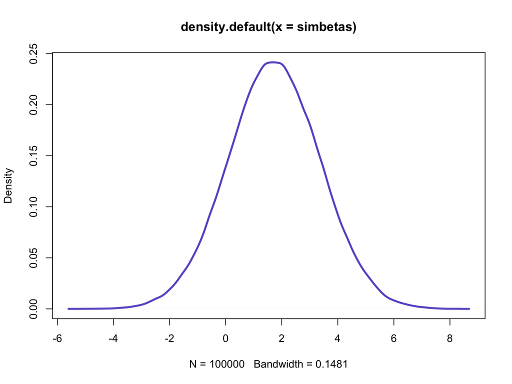

```r
simbetas <- rnorm(100000, mle, sqrt(vcov))
par(mfrow=c(1,1))
plot(density(simbetas), col="slateblue", lwd=3)
```

2. Simulate predicted value

Let’s say we get data for one more observation and we want to predict the probability of $y=1$

```r
new_obs <- .45 # our new data point

cov <- simbetas * new_obs
pred.p <- 1 / (1+exp(-cov))
mean(pred.p)
```

```
## [1] 0.6671791
```

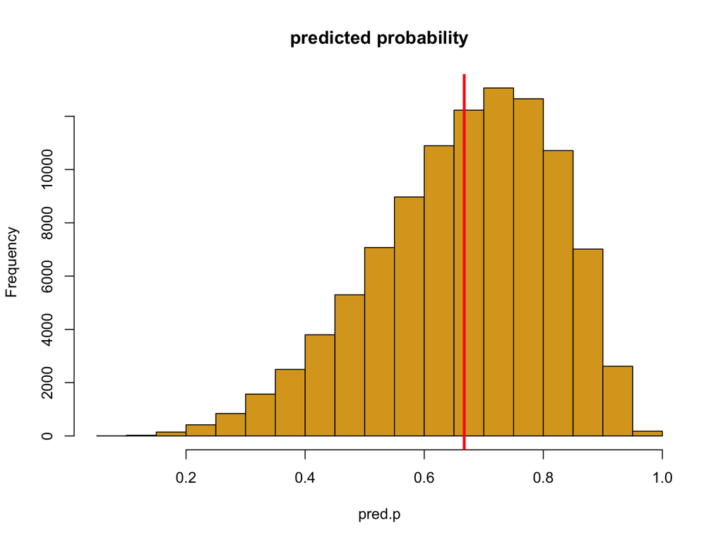

```r
hist(pred.p, col="goldenrod", main="predicted probability")
abline(v=mean(pred.p), col="red", lwd=3)
```

```r
quantile(pred.p, probs = c(0.25, 0.75))
```

```
##       25%       75%
## 0.5697554 0.7822253
```

3. Simulate expected values

```r
# for the binomial distribution, the expected value equals
# the rate, so to get the expected value we can just take
# the expectation of the predicted probabilities (for other
# distributions this might not hold, and we might want to
# do the simulation of the stochastic component as well)
# so here we could just do
mean(pred.p)
```

```
## [1] 0.6671791
```

Simulate first differences

```r
new_obs
```

```
## [1] 0.45
```

```r
new_obs.better <- 0.65

cov <- simbetas * new_obs.better
pred.p.2 <- 1 / (1 + exp(-cov))

# to get the expected value, here we can again just take the
# mean of the predicted probabilities
mean(pred.p.2)
```

```
## [1] 0.7145223
```

```r
#now lets get the first difference
firs.diff <- mean(pred.p.2) - mean(pred.p)
firs.diff
```

```
## [1] 0.04734319
```

An increase in the independent variable is associated with an increase in the outcome.

Predicted probabilities plot

How would we do the plot of predicted probabilities?

```r
# Let's take values of X from -1 to 1
x_sim <- seq(-1, 1, by=.01)

pred.prob <- matrix(NA, length(x_sim), 3)

for(i in 1:length(x_sim)){

    cov <- simbetas * x_sim[i]
    pred.p <- 1/(1+exp(-cov))

    pred.prob[i,1] <- mean(pred.p)

    # And we can simulate 90% CIs:
    pred.prob[i,2] <- quantile(pred.p, probs=.05) # lower CI
    pred.prob[i,3] <- quantile(pred.p, probs=.95) # upper CI
}

head(pred.prob)
```

```
##           [,1]       [,2]      [,3]
## [1,] 0.2331623 0.01168301 0.7271555
## [2,] 0.2342665 0.01220669 0.7252064
## [3,] 0.2353892 0.01275354 0.7232486
## [4,] 0.2365307 0.01332456 0.7212823
## [5,] 0.2376914 0.01392079 0.7193074
## [6,] 0.2388717 0.01454330 0.7173240
```

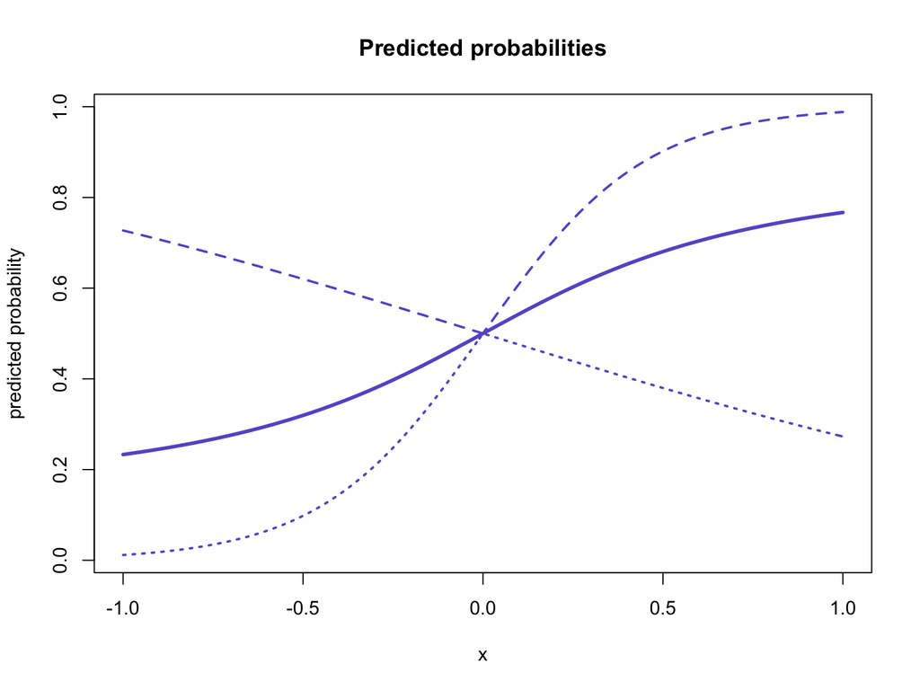

```r
plot(x_sim, pred.prob[,1],
     col="slateblue", type="l",
     lty=1, lwd=3, main="Predicted probabilities",
     xlab="x", ylab="predicted probability", ylim=c(min(pred.prob), max(pred.prob)))
lines(x_sim,pred.prob[,2], col="slateblue", type="l", lty=3, lwd=2 )
lines(x_sim,pred.prob[,3], col="slateblue", type="l", lty=2, lwd=2 )
```

# Log odds

- Odds ratio: probability of a “success” to probability of a “failure”
  $$\frac{p}{1- p} = e^{X\beta}$$
- Log odds ratio: $X\beta$